# 01_pandas

### 리스트

```python
myfood = ['banana', 'apple', 'candy']
print(myfood[0])
print(myfood[1])
print(myfood[2])
```

```
banana
apple
candy
```

```python
for item in myfood:
  print(item)
```

```
banana
apple
candy
```

### 딕셔너리

```python
dict1 = {'one':'하나', 'two':"둘", 'three':'셋'}
dict2 = {1:"하나", 2:"둘", 3:"셋"}
dict3 = {'col1':[1,2,3], 'col2':['a','b','c']}
```

```python
print(dict1)
print(dict2)
print(dict3)
```

```
{'one': '하나', 'two': '둘', 'three': '셋'}
{1: '하나', 2: '둘', 3: '셋'}
{'col1': [1, 2, 3], 'col2': ['a', 'b', 'c']}
```

### pandas 모듈 불러오기

```python
import pandas as pd
from pandas import Series, DataFrame
import matplotlib as mpl
```

#### 버젼 확인

```python
print('pandas version : ', pd.__version__)
print('matplotlib version: ', mpl.__version__)
```

```
pandas version :  1.2.4
matplotlib version:  3.3.4
```

### Series 만들기

```python
## ___ = Series( [1000, 14000, 3000, 3000, 1000] )
score = Series( [1000, 14000, 3000, 3000, 1000] )
print(score)
```

```
0     1000
1    14000
2     3000
3     3000
4     1000
dtype: int64
```

```python
type(score)
```

```
pandas.core.series.Series
```

##### score 인덱스, 값 확인

```python
print(score.index)
print(list(score.index))
print(score.values)

print(type(score.index))
print(type(list(score.index)))
print(type(score.values))
```

```
RangeIndex(start=0, stop=5, step=1)
[0, 1, 2, 3, 4]
[ 1000 14000  3000  3000  1000]
<class 'pandas.core.indexes.range.RangeIndex'>
<class 'list'>
<class 'numpy.ndarray'>
```

```python
score = Series( [1000, 14000, 3000],
               index = ['2019-05-01', '2019-05-02', '2019-05-03'] )

print(score)
```

```
2019-05-01     1000
2019-05-02    14000
2019-05-03     3000
dtype: int64
```

### 실습 1-1 Series 만들기 (자료형으로 만들기)

```python
# 1-1
price = Series([100000, 200000, 400000, 800000, 1600000])
print(price)
```

```
0     100000
1     200000
2     400000
3     800000
4    1600000
dtype: int64
```

### 실습 1-2 index를 넣어보기

```python
# 1-2
price = Series([100000, 200000, 400000, 800000, 1600000],
              index = ['mon','tue','wed','thu','fri'])
print(price)
```

```
mon     100000
tue     200000
wed     400000
thu     800000
fri    1600000
dtype: int64
```

```python
for idx in score.index:
    print(idx)
```

```
2019-05-01
2019-05-02
2019-05-03
```

```python
for value in score.values:
    print(value)
```

```
1000
14000
3000
```

##### 참고) index가 많을 때

```python
idx = pd.date_range(start="2020-01-01",end="2020-01-03").tolist()

score_idx = Series( ['a', 'b', 'c'],
                   index=idx )
score_idx
```

```
2020-01-01    a
2020-01-02    b
2020-01-03    c
dtype: object
```

### 두 팀의 점수 합산

#### 1-4 실습확인

```python
gildong = Series([1500, 300, 2500],
                 index = ['2019-05-01', '2019-05-02', '2019-05-03'])

toto = Series([3000, 3000, 2000],
             index = ['2019-05-01', '2019-05-02', '2019-05-03'])
```

```python
gildong + toto
```

```
2019-05-01    4500
2019-05-02    3300
2019-05-03    4500
dtype: int64
```

#### 1-4 추가 실습 - 날짜를idx를 date_range함수를 이용해서 넣어보기

```python
idx = pd.date_range(start='2019-05-01', end='2019-05-03').tolist()

gildong = Series([1500, 300, 2500],
                index = idx)
toto = Series([3000, 3000, 2000],
             index = idx)

gildong, toto
```

```
(2019-05-01    1500
 2019-05-02     300
 2019-05-03    2500
 dtype: int64,
 2019-05-01    3000
 2019-05-02    3000
 2019-05-03    2000
 dtype: int64)
```

```python
### 1-4 (추가) 데이터는 3개월 날짜 1~90까지, idx를 3개월 날짜로 지정하기(1월~3월) - 댓글 추가
date = []
for i in range(1,91):
    date.append(i)
idx = pd.date_range(start='2019-01-01', end='2019-03-31').tolist()

test = Series(date, idx)

test
```

```
2019-01-01     1
2019-01-02     2
2019-01-03     3
2019-01-04     4
2019-01-05     5
              ..
2019-03-27    86
2019-03-28    87
2019-03-29    88
2019-03-30    89
2019-03-31    90
Length: 90, dtype: int64
```

## 데이터 프레임의 이해

- Pandas(판다스)의 대표적인 기본 자료형
- Seaborn 데이터(load_dataset() - pandas)
  - seaborn에 들어가는 기본적인 데이터 자료형 pandas
- plotly에서도 pandas 호환

```python
from pandas import DataFrame
```

```python
dat = { 'col1' : [1,2,3,4],
        'col2' : [10,20,30,40],
        'col3' : ['A', 'B', 'C', 'D'] }
df = DataFrame(dat)
df
```

|  | col1 | col2 | col3 |
| --- | --- | --- | --- |
| 0 | 1 | 10 | A |
| 1 | 2 | 20 | B |
| 2 | 3 | 30 | C |
| 3 | 4 | 40 | D |

#### 1-5 (추가) 나만의 데이터 프레임 만들기

```python
dat = { '맛있는 음식' : ['삼겹살','된장찌개','김치찌개'],
       '운동' : ['달리기','풋살','요가']}
df = DataFrame(dat)
df
```

|  | 맛있는 음식 | 운동 |
| --- | --- | --- |
| 0 | 삼겹살 | 달리기 |
| 1 | 된장찌개 | 풋살 |
| 2 | 김치찌개 | 요가 |

### 데이터 프레임에 인덱스 추가하기

```python
idx_date = pd.date_range(start='2020-01-01', end='2020-01-04').tolist()
```

```python
dat = { 'col1' : [1,2,3,4],
        'col2' : [10,20,30,40],
        'col3' : ['A', 'B', 'C', 'D'] }
df = DataFrame(dat, index = idx_date)
df
```

|  | col1 | col2 | col3 |
| --- | --- | --- | --- |
| 2020-01-01 | 1 | 10 | A |
| 2020-01-02 | 2 | 20 | B |
| 2020-01-03 | 3 | 30 | C |
| 2020-01-04 | 4 | 40 | D |

```python
# 열 순서 바꾸기(위의 df와 비교)
dat = { 'col1' : [1,2,3,4],
        'col2' : [10,20,30,40],
        'col3' : ['A', 'B', 'C', 'D'] }
df2 = DataFrame(dat, columns = ['col2', 'col1', 'col3'], index = idx_date)
df2
```

|  | col2 | col1 | col3 |
| --- | --- | --- | --- |
| 2020-01-01 | 10 | 1 | A |
| 2020-01-02 | 20 | 2 | B |
| 2020-01-03 | 30 | 3 | C |
| 2020-01-04 | 40 | 4 | D |

### 데이터에 접근하기

```python
from pandas import DataFrame

team_score = { "toto":[1500,3000,5000,7000,5500],
               "apple":[4000,5000,6000,5500,4500],
               "gildong":[2000,2500,3000,4000,3000],
               "catanddog":[7000,5000,3000,5000,4000]}

team_df = DataFrame(team_score)
team_df
```

|  | toto | apple | gildong | catanddog |
| --- | --- | --- | --- | --- |
| 0 | 1500 | 4000 | 2000 | 7000 |
| 1 | 3000 | 5000 | 2500 | 5000 |
| 2 | 5000 | 6000 | 3000 | 3000 |
| 3 | 7000 | 5500 | 4000 | 5000 |
| 4 | 5500 | 4500 | 3000 | 4000 |

```python
team_df['toto']
```

```
0    1500
1    3000
2    5000
3    7000
4    5500
Name: toto, dtype: int64
```

#### 2개의 열선택

```python
sel = ['toto', 'apple']
team_df[sel]
```

|  | toto | apple |
| --- | --- | --- |
| 0 | 1500 | 4000 |
| 1 | 3000 | 5000 |
| 2 | 5000 | 6000 |
| 3 | 7000 | 5500 |
| 4 | 5500 | 4500 |

```python
# 2개의 열 선택(오류)
team_df['toto', 'apple']
```

[output not shown]

```python
# 해결(대괄호로 묶어야 한다.)
team_df[ ['toto', 'apple'] ]
```

|  | toto | apple |
| --- | --- | --- |
| 0 | 1500 | 4000 |
| 1 | 3000 | 5000 |
| 2 | 5000 | 6000 |
| 3 | 7000 | 5500 |
| 4 | 5500 | 4500 |

```python
# 2 개의 열 선택
# team_df.loc[]
# team_df.iloc[]
```

```python
team_df
```

|  | toto | apple | gildong | catanddog |
| --- | --- | --- | --- | --- |
| 0 | 1500 | 4000 | 2000 | 7000 |
| 1 | 3000 | 5000 | 2500 | 5000 |
| 2 | 5000 | 6000 | 3000 | 3000 |
| 3 | 7000 | 5500 | 4000 | 5000 |
| 4 | 5500 | 4500 | 3000 | 4000 |

```python
# team_df.loc[ 행 선택, 열 선택]
team_df.loc[ 0:2, ['toto', 'gildong'] ]
```

|  | toto | gildong |
| --- | --- | --- |
| 0 | 1500 | 2000 |
| 1 | 3000 | 2500 |
| 2 | 5000 | 3000 |

```python
team_df.loc[ [0, 2, 4], ['toto', 'gildong'] ]
```

|  | toto | gildong |
| --- | --- | --- |
| 0 | 1500 | 2000 |
| 2 | 5000 | 3000 |
| 4 | 5500 | 3000 |

```python
team_df.loc[ :, : ] # 전체 선택
```

|  | toto | apple | gildong | catanddog |
| --- | --- | --- | --- | --- |
| 0 | 1500 | 4000 | 2000 | 7000 |
| 1 | 3000 | 5000 | 2500 | 5000 |
| 2 | 5000 | 6000 | 3000 | 3000 |
| 3 | 7000 | 5500 | 4000 | 5000 |
| 4 | 5500 | 4500 | 3000 | 4000 |

```python
# gildong 열 선택
team_df.loc[:, ['gildong'] ] # DataFrame 형태
```

|  | gildong |
| --- | --- |
| 0 | 2000 |
| 1 | 2500 |
| 2 | 3000 |
| 3 | 4000 |
| 4 | 3000 |

```python
team_df.loc[:, 'gildong' ] # Series 형태
```

```
0    2000
1    2500
2    3000
3    4000
4    3000
Name: gildong, dtype: int64
```

```python
# gildong, catanddog 열 선택
team_df.loc[ :, ['gildong','catanddog'] ]
```

|  | gildong | catanddog |
| --- | --- | --- |
| 0 | 2000 | 7000 |
| 1 | 2500 | 5000 |
| 2 | 3000 | 3000 |
| 3 | 4000 | 5000 |
| 4 | 3000 | 4000 |

```python
sel =['gildong','catanddog']
team_df.loc[ :, sel ]
```

|  | gildong | catanddog |
| --- | --- | --- |
| 0 | 2000 | 7000 |
| 1 | 2500 | 5000 |
| 2 | 3000 | 3000 |
| 3 | 4000 | 5000 |
| 4 | 3000 | 4000 |

```python
# 1행에서 3행까지 toto에서 gildong까지 선택
team_df.loc[ 1:3, 'toto':'gildong']
```

|  | toto | apple | gildong |
| --- | --- | --- | --- |
| 1 | 3000 | 5000 | 2500 |
| 2 | 5000 | 6000 | 3000 |
| 3 | 7000 | 5500 | 4000 |

```python
# 1행과 3행 전체 선택
team_df.loc[ [1,3], : ]
```

|  | toto | apple | gildong | catanddog |
| --- | --- | --- | --- | --- |
| 1 | 3000 | 5000 | 2500 | 5000 |
| 3 | 7000 | 5500 | 4000 | 5000 |

```python
team_df.loc[ [1,3] ] # 행만 선택하면 그 행 전체 출력
```

|  | toto | apple | gildong | catanddog |
| --- | --- | --- | --- | --- |
| 1 | 3000 | 5000 | 2500 | 5000 |
| 3 | 7000 | 5500 | 4000 | 5000 |

```python
# 2열, 4열 선택하기
team_df.loc[ :, ['apple','catanddog'] ]
```

[output not shown]

```python
# 2열, 4열 선택하기
# team_df.loc[ :, ['apple','catanddog'] ]
team_df[ ['apple','catanddog'] ] # 동일한 결과(loc쓰지 않음)
```

[output not shown]

```python
team_df.loc[ [1,3], ['apple','catanddog'] ]
```

|  | apple | catanddog |
| --- | --- | --- |
| 1 | 5000 | 5000 |
| 3 | 5500 | 5000 |

```python
team_df.loc[ 2:3, 'apple':'catanddog' ]
```

|  | apple | gildong | catanddog |
| --- | --- | --- | --- |
| 2 | 6000 | 3000 | 3000 |
| 3 | 5500 | 4000 | 5000 |

```python
team_df.loc[ 2:3, 'apple': ]
```

|  | apple | gildong | catanddog |
| --- | --- | --- | --- |
| 2 | 6000 | 3000 | 3000 |
| 3 | 5500 | 4000 | 5000 |

```python
team_df.iloc[ :, :]
```

|  | toto | apple | gildong | catanddog |
| --- | --- | --- | --- | --- |
| 0 | 1500 | 4000 | 2000 | 7000 |
| 1 | 3000 | 5000 | 2500 | 5000 |
| 2 | 5000 | 6000 | 3000 | 3000 |
| 3 | 7000 | 5500 | 4000 | 5000 |
| 4 | 5500 | 4500 | 3000 | 4000 |

```python
# 1행만 선택
team_df.iloc[ [0], :] # 데이터 프레임 형태
```

|  | toto | apple | gildong | catanddog |
| --- | --- | --- | --- | --- |
| 0 | 1500 | 4000 | 2000 | 7000 |

```python
# 1행만 선택
team_df.iloc[ [0] ] # 행만 선택하면 그 행 전체 출력(데이터 프레임 형태)
```

|  | toto | apple | gildong | catanddog |
| --- | --- | --- | --- | --- |
| 0 | 1500 | 4000 | 2000 | 7000 |

```python
team_df.iloc[ 0, :] # 시리즈 형태
```

```
toto         1500
apple        4000
gildong      2000
catanddog    7000
Name: 0, dtype: int64
```

```python
team_df.iloc[ 0 ] # 행만 선택하면 그 행 전체 출력(시리즈)
```

```
toto         1500
apple        4000
gildong      2000
catanddog    7000
Name: 0, dtype: int64
```

```python
# 2, 4행 선택
team_df.iloc[[2, 4], :]
```

|  | toto | apple | gildong | catanddog |
| --- | --- | --- | --- | --- |
| 2 | 5000 | 6000 | 3000 | 3000 |
| 4 | 5500 | 4500 | 3000 | 4000 |

```python
# 2, 4행 선택
team_df.iloc[[2, 4]] # 행만 선택하면 그 행 전체 출력
```

|  | toto | apple | gildong | catanddog |
| --- | --- | --- | --- | --- |
| 2 | 5000 | 6000 | 3000 | 3000 |
| 4 | 5500 | 4500 | 3000 | 4000 |

```python
# 1~4행, 1~2열 선택
team_df.iloc[ 1:5 , 1:3 ]
```

|  | apple | gildong |
| --- | --- | --- |
| 1 | 5000 | 2500 |
| 2 | 6000 | 3000 |
| 3 | 5500 | 4000 |
| 4 | 4500 | 3000 |

```python
# 1~4행, 1~2열 선택(데이터 끝까지 선택이라 간략한 표현가능)
team_df.iloc[ 1: , 1:3 ]
```

|  | apple | gildong |
| --- | --- | --- |
| 1 | 5000 | 2500 |
| 2 | 6000 | 3000 |
| 3 | 5500 | 4000 |
| 4 | 4500 | 3000 |

```python
# 1~2행, 1, 3열 선택
team_df.iloc[ 1:3 , [1,3] ]
```

|  | apple | catanddog |
| --- | --- | --- |
| 1 | 5000 | 5000 |
| 2 | 6000 | 3000 |

```python
# 1~2행, 1, 3열 선택(다른 방법)
team_df.iloc[ 1:3 , 1:4:2 ]
```

|  | apple | catanddog |
| --- | --- | --- |
| 1 | 5000 | 5000 |
| 2 | 6000 | 3000 |

### loc와 iloc를 이용한 접근

```python
idx_date = pd.date_range(start="2019-05-01",end="2019-05-05").tolist()
team_df.index = idx_date
team_df
```

|  | toto | apple | gildong | catanddog |
| --- | --- | --- | --- | --- |
| 2019-05-01 | 1500 | 4000 | 2000 | 7000 |
| 2019-05-02 | 3000 | 5000 | 2500 | 5000 |
| 2019-05-03 | 5000 | 6000 | 3000 | 3000 |
| 2019-05-04 | 7000 | 5500 | 4000 | 5000 |
| 2019-05-05 | 5500 | 4500 | 3000 | 4000 |

```python
print(team_df.loc[ '2019-05-02' ] ) # 19-05-02 일
print("-----------")
print(team_df.loc[ ['2019-05-02', '2019-05-03'] ]) # 5월 2일, 3일
print("-----------")
print(team_df.loc[ '2019-05-02': ])  # 5월 2일 이후 전체 데이터 가져오기
```

```
toto         3000
apple        5000
gildong      2500
catanddog    5000
Name: 2019-05-02 00:00:00, dtype: int64
-----------
            toto  apple  gildong  catanddog
2019-05-02  3000   5000     2500       5000
2019-05-03  5000   6000     3000       3000
-----------
            toto  apple  gildong  catanddog
2019-05-02  3000   5000     2500       5000
2019-05-03  5000   6000     3000       3000
2019-05-04  7000   5500     4000       5000
2019-05-05  5500   4500     3000       4000
```

```python
## 컬럼명 확인
print(team_df.columns)
print("-----")
print(team_df.loc[:, 'toto'])   # 전체행, toto팀
print("-----")
print(team_df.loc[:, ['toto', 'gildong'] ])   # 전체행, toto, gildong팀
print("-----")
print(team_df.loc[:, 'toto': ])   # 전체행, toto 부터 끝까지
```

```
Index(['toto', 'apple', 'gildong', 'catanddog'], dtype='object')
-----
2019-05-01    1500
2019-05-02    3000
2019-05-03    5000
2019-05-04    7000
2019-05-05    5500
Name: toto, dtype: int64
-----
            toto  gildong
2019-05-01  1500     2000
2019-05-02  3000     2500
2019-05-03  5000     3000
2019-05-04  7000     4000
2019-05-05  5500     3000
-----
            toto  apple  gildong  catanddog
2019-05-01  1500   4000     2000       7000
2019-05-02  3000   5000     2500       5000
2019-05-03  5000   6000     3000       3000
2019-05-04  7000   5500     4000       5000
2019-05-05  5500   4500     3000       4000
```

### iloc 속성을 이용한 행, 열 데이터 접근하기

```python
print(team_df.iloc[0])      # 첫번째 행 접근
print("------")
print(team_df.iloc[ [0,1] ])  # 첫번째 두번째 행 접근
print("------")
print(team_df.iloc[ 0:3:1] )  # 첫번째부터 세번째 행 접근
print("------")
range_num = list(range(0,3,1))
print(team_df.iloc[ range_num ] )  # 첫번째부터 세번째 행 접근
```

```
toto         1500
apple        4000
gildong      2000
catanddog    7000
Name: 2019-05-01 00:00:00, dtype: int64
------
            toto  apple  gildong  catanddog
2019-05-01  1500   4000     2000       7000
2019-05-02  3000   5000     2500       5000
------
            toto  apple  gildong  catanddog
2019-05-01  1500   4000     2000       7000
2019-05-02  3000   5000     2500       5000
2019-05-03  5000   6000     3000       3000
------
            toto  apple  gildong  catanddog
2019-05-01  1500   4000     2000       7000
2019-05-02  3000   5000     2500       5000
2019-05-03  5000   6000     3000       3000
```

### 일반 통계 - 합, 평균, 표준편차, ...

```python
# 열 별 합
team_df.sum()
```

```
toto         22000
apple        25000
gildong      14500
catanddog    24000
dtype: int64
```

```python
team_df.sum(axis=0) # index(열) 별 합 : (0), 행 별 합 : (1), 기본은 index별 합.
```

```
toto         22000
apple        25000
gildong      14500
catanddog    24000
dtype: int64
```

```python
team_df.sum(axis=1)
```

```
2019-05-01    14500
2019-05-02    15500
2019-05-03    17000
2019-05-04    21500
2019-05-05    17000
dtype: int64
```

#### 실습 4-2 통계량 구하기

```python
# 평균
print(team_df.mean())
# 표준편차
print(team_df.std())
```

```
toto         4400.0
apple        5000.0
gildong      2900.0
catanddog    4800.0
dtype: float64
toto         2162.174831
apple         790.569415
gildong       741.619849
catanddog    1483.239697
dtype: float64
```

#### 4-3 (추가) 그외 통계량 구하기 - 댓글

```python
team_df.count()
```

```
toto         5
apple        5
gildong      5
catanddog    5
dtype: int64
```

```python
team_df['toto'].sum() # toto 열의 합계
```

```
22000
```

```python
team_df.count()
```

```
toto         5
apple        5
gildong      5
catanddog    5
dtype: int64
```

```python
team_df.count().values
```

```
array([5, 5, 5, 5], dtype=int64)
```

```python
team_df.count().index
```

```
Index(['toto', 'apple', 'gildong', 'catanddog'], dtype='object')
```

```python
team_df[['toto','gildong']].sum()
```

```
toto       22000
gildong    14500
dtype: int64
```

```python
team_df
```

|  | toto | apple | gildong | catanddog |
| --- | --- | --- | --- | --- |
| 2019-05-01 | 1500 | 4000 | 2000 | 7000 |
| 2019-05-02 | 3000 | 5000 | 2500 | 5000 |
| 2019-05-03 | 5000 | 6000 | 3000 | 3000 |
| 2019-05-04 | 7000 | 5500 | 4000 | 5000 |
| 2019-05-05 | 5500 | 4500 | 3000 | 4000 |

#### 4-4 실습 - apple과 catanddog의 sum(), mean(), std()

```python
print(team_df[['apple','catanddog']].sum())
print("===================")
print(team_df[['apple','catanddog']].mean())
print("===================")
print(team_df[['apple','catanddog']].std())
```

```
apple        25000
catanddog    24000
dtype: int64
===================
apple        5000.0
catanddog    4800.0
dtype: float64
===================
apple         790.569415
catanddog    1483.239697
dtype: float64
```

#### 4-4 (추가) team_df의 sum()을 구하고 기존의 team_df에 추가해 보자.

```python
team_sum = team_df.sum()
team_sum
```

```
toto         22000
apple        25000
gildong      14500
catanddog    24000
dtype: int64
```

```python
team_df['row_sum'] = team_df.sum(axis=1)
team_df
```

|  | toto | apple | gildong | catanddog | row_sum |
| --- | --- | --- | --- | --- | --- |
| 2019-05-01 | 1500 | 4000 | 2000 | 7000 | 14500 |
| 2019-05-02 | 3000 | 5000 | 2500 | 5000 | 15500 |
| 2019-05-03 | 5000 | 6000 | 3000 | 3000 | 17000 |
| 2019-05-04 | 7000 | 5500 | 4000 | 5000 | 21500 |
| 2019-05-05 | 5500 | 4500 | 3000 | 4000 | 17000 |

```python
### titanic 데이터 셋으로 요약 보고서 작성
import seaborn as sns

t = sns.load_dataset('titanic')
t
```

|  | survived | pclass | sex | age | sibsp | parch | fare | embarked | class | who | adult_male | deck | embark_town | alive | alone |
| --- | --- | --- | --- | --- | --- | --- | --- | --- | --- | --- | --- | --- | --- | --- | --- |
| 0 | 0 | 3 | male | 22.0 | 1 | 0 | 7.2500 | S | Third | man | True | NaN | Southampton | no | False |
| 1 | 1 | 1 | female | 38.0 | 1 | 0 | 71.2833 | C | First | woman | False | C | Cherbourg | yes | False |
| 2 | 1 | 3 | female | 26.0 | 0 | 0 | 7.9250 | S | Third | woman | False | NaN | Southampton | yes | True |
| 3 | 1 | 1 | female | 35.0 | 1 | 0 | 53.1000 | S | First | woman | False | C | Southampton | yes | False |
| 4 | 0 | 3 | male | 35.0 | 0 | 0 | 8.0500 | S | Third | man | True | NaN | Southampton | no | True |
| ... | ... | ... | ... | ... | ... | ... | ... | ... | ... | ... | ... | ... | ... | ... | ... |
| 886 | 0 | 2 | male | 27.0 | 0 | 0 | 13.0000 | S | Second | man | True | NaN | Southampton | no | True |
| 887 | 1 | 1 | female | 19.0 | 0 | 0 | 30.0000 | S | First | woman | False | B | Southampton | yes | True |
| 888 | 0 | 3 | female | NaN | 1 | 2 | 23.4500 | S | Third | woman | False | NaN | Southampton | no | False |
| 889 | 1 | 1 | male | 26.0 | 0 | 0 | 30.0000 | C | First | man | True | C | Cherbourg | yes | True |
| 890 | 0 | 3 | male | 32.0 | 0 | 0 | 7.7500 | Q | Third | man | True | NaN | Queenstown | no | True |

891 rows × 15 columns

#### 4-5 데이터 셋 추가 실습 - 행 선택, 열 선택, 통계 값 구하기(sum(), mean(), count() ) 그리고 이에 대한 통계량을 추가해보기

```python
# 클래스별 운임의 평균, 최대, 최소값
fare_by_class = t[['pclass', 'fare']]
fare_by_class
```

|  | pclass | fare |
| --- | --- | --- |
| 0 | 3 | 7.2500 |
| 1 | 1 | 71.2833 |
| 2 | 3 | 7.9250 |
| 3 | 1 | 53.1000 |
| 4 | 3 | 8.0500 |
| ... | ... | ... |
| 886 | 2 | 13.0000 |
| 887 | 1 | 30.0000 |
| 888 | 3 | 23.4500 |
| 889 | 1 | 30.0000 |
| 890 | 3 | 7.7500 |

891 rows × 2 columns

```python
# 클래스 별 리스트 작성
cl_fare1 = []
cl_fare2 = []
cl_fare3 = []

for i in range(len(fare_by_class)):
    if fare_by_class.iloc[i,0] == 1:
        cl_fare1.append(fare_by_class.iloc[i,1])
for i in range(len(fare_by_class)):
    if fare_by_class.iloc[i,0] == 2:
        cl_fare2.append(fare_by_class.iloc[i,1])
for i in range(len(fare_by_class)):
    if fare_by_class.iloc[i,0] == 3:
        cl_fare3.append(fare_by_class.iloc[i,1])

cl_fare1 = Series(cl_fare1)
cl_fare2 = Series(cl_fare2)
cl_fare3 = Series(cl_fare3)

print(cl_fare1)
print(cl_fare2)
print(cl_fare3)
```

```
0      71.2833
1      53.1000
2      51.8625
3      26.5500
4      35.5000
        ...
211    52.5542
212     5.0000
213    83.1583
214    30.0000
215    30.0000
Length: 216, dtype: float64
0      30.0708
1      16.0000
2      13.0000
```

[output cut: 21 more lines]

```python
# 클래스 별 요금 평균, 최고, 최저가
print('============1 등석============')
print("1등석 요금 평균 :", cl_fare1.mean())
print("1등석 요금 최고 :", cl_fare1.max())
print("1등석 요금 최저 :", cl_fare1.min())
print('============2 등석============')
print("1등석 요금 평균 :", cl_fare2.mean())
print("1등석 요금 최고 :", cl_fare2.max())
print("1등석 요금 최저 :", cl_fare2.min())
print('============3 등석============')
print("1등석 요금 평균 :", cl_fare3.mean())
print("1등석 요금 최고 :", cl_fare3.max())
print("1등석 요금 최저 :", cl_fare3.min())
```

```
============1 등석============
1등석 요금 평균 : 84.15468749999992
1등석 요금 최고 : 512.3292
1등석 요금 최저 : 0.0
============2 등석============
1등석 요금 평균 : 20.66218315217391
1등석 요금 최고 : 73.5
1등석 요금 최저 : 0.0
============3 등석============
1등석 요금 평균 : 13.675550101832997
1등석 요금 최고 : 69.55
1등석 요금 최저 : 0.0
```

```python
## t.columns : 컬럼명 확인
## t.shape : 행과 열 확인
## t.describe() : 통계량 확인
## t.head() : 앞의 5행 보기
## t.tail() : 뒤의 5행 보기
```

```python
t.columns
```

```
Index(['survived', 'pclass', 'sex', 'age', 'sibsp', 'parch', 'fare',
       'embarked', 'class', 'who', 'adult_male', 'deck', 'embark_town',
       'alive', 'alone'],
      dtype='object')
```

```python
from pandas import DataFrame

team_score = { "toto":[1500,3000,5000,7000,5500],
               "apple":[4000,5000,6000,5500,4500],
               "gildong":[2000,2500,3000,4000,3000],
               "catanddog":[7000,5000,3000,5000,4000]}

team_df = DataFrame(team_score)
idx_date = pd.date_range(start="2019-05-01",end="2019-05-05").tolist()
team_df.index = idx_date
team_df['row_sum'] = team_df.sum(axis=1)
```

```python
team_df
```

|  | toto | apple | gildong | catanddog | row_sum |
| --- | --- | --- | --- | --- | --- |
| 2019-05-01 | 1500 | 4000 | 2000 | 7000 | 14500 |
| 2019-05-02 | 3000 | 5000 | 2500 | 5000 | 15500 |
| 2019-05-03 | 5000 | 6000 | 3000 | 3000 | 17000 |
| 2019-05-04 | 7000 | 5500 | 4000 | 5000 | 21500 |
| 2019-05-05 | 5500 | 4500 | 3000 | 4000 | 17000 |

```python
team_df['row_sum'].sort_values(ascending=False) # 컬럼 명이 명령어와 겹치는 경우를 방지(team_df.row_sum과 같은 의미의 코드)
```

```
2019-05-04    21500
2019-05-03    17000
2019-05-05    17000
2019-05-02    15500
2019-05-01    14500
Name: row_sum, dtype: int64
```

```python
team_df.row_sum.sort_values(ascending=False) # 위와 같은 의미의 코드
```

```
2019-05-04    21500
2019-05-03    17000
2019-05-05    17000
2019-05-02    15500
2019-05-01    14500
Name: row_sum, dtype: int64
```

#### 5-3 실습 - 행의 평균을 구하고, 구한 값을 정렬시켜보자.

```python
team_df["row_mean"] = team_df.iloc[:,0:4].mean(axis=1)
team_df
```

|  | toto | apple | gildong | catanddog | row_sum | row_mean |
| --- | --- | --- | --- | --- | --- | --- |
| 2019-05-01 | 1500 | 4000 | 2000 | 7000 | 14500 | 3625.0 |
| 2019-05-02 | 3000 | 5000 | 2500 | 5000 | 15500 | 3875.0 |
| 2019-05-03 | 5000 | 6000 | 3000 | 3000 | 17000 | 4250.0 |
| 2019-05-04 | 7000 | 5500 | 4000 | 5000 | 21500 | 5375.0 |
| 2019-05-05 | 5500 | 4500 | 3000 | 4000 | 17000 | 4250.0 |

```python
team_df['row_mean'].sort_values(ascending=False) # ascending=False : 내림차순, ascending=True : 오름차순
```

```
2019-05-04    5375.0
2019-05-03    4250.0
2019-05-05    4250.0
2019-05-02    3875.0
2019-05-01    3625.0
Name: row_mean, dtype: float64
```

```python
team_df.sort_values('row_mean', ascending=False) # sort_values먼저 입력후 열 선택해도 가능(위와 같은 의미 코드, 데이터 프레임 형태)
```

|  | toto | apple | gildong | catanddog | row_sum | row_mean |
| --- | --- | --- | --- | --- | --- | --- |
| 2019-05-04 | 7000 | 5500 | 4000 | 5000 | 21500 | 5375.0 |
| 2019-05-03 | 5000 | 6000 | 3000 | 3000 | 17000 | 4250.0 |
| 2019-05-05 | 5500 | 4500 | 3000 | 4000 | 17000 | 4250.0 |
| 2019-05-02 | 3000 | 5000 | 2500 | 5000 | 15500 | 3875.0 |
| 2019-05-01 | 1500 | 4000 | 2000 | 7000 | 14500 | 3625.0 |

```python
## 자료형 - 시리즈, 데이터 프레임
##
## 행과 열을 선택 : loc, iloc
## date_range()
## 새로운 열을 추가하는 것에 대해 배우다. __['새로운 컬럼명' ] = ___
## 통게량 구하기 [].sum(), mean(), std(), axis=0(각 열의 최종합, 행들의 합)
##   axis = 1 (행의 합, columns들의 합)
## 갑을 정렬 sort_values()
```

```python
team_df
```

|  | toto | apple | gildong | catanddog | row_sum | row_mean |
| --- | --- | --- | --- | --- | --- | --- |
| 2019-05-01 | 1500 | 4000 | 2000 | 7000 | 14500 | 3625.0 |
| 2019-05-02 | 3000 | 5000 | 2500 | 5000 | 15500 | 3875.0 |
| 2019-05-03 | 5000 | 6000 | 3000 | 3000 | 17000 | 4250.0 |
| 2019-05-04 | 7000 | 5500 | 4000 | 5000 | 21500 | 5375.0 |
| 2019-05-05 | 5500 | 4500 | 3000 | 4000 | 17000 | 4250.0 |

#### 5-4 조건을 걸어 데이터를 뽑기- 행이 합이 15000이상인 값을 뽑는다.

```python
team_df.loc[team_df['row_sum'] >= 15000 , : ]
```

|  | toto | apple | gildong | catanddog | row_sum | row_mean |
| --- | --- | --- | --- | --- | --- | --- |
| 2019-05-02 | 3000 | 5000 | 2500 | 5000 | 15500 | 3875.0 |
| 2019-05-03 | 5000 | 6000 | 3000 | 3000 | 17000 | 4250.0 |
| 2019-05-04 | 7000 | 5500 | 4000 | 5000 | 21500 | 5375.0 |
| 2019-05-05 | 5500 | 4500 | 3000 | 4000 | 17000 | 4250.0 |

#### 5-4 (추가) 5월 3일이상, row_sum이 15000이상

```python
a = team_df.loc['2019-05-03':, :]
a.loc[a['row_sum']>=15000,:]
```

|  | toto | apple | gildong | catanddog | row_sum | row_mean |
| --- | --- | --- | --- | --- | --- | --- |
| 2019-05-03 | 5000 | 6000 | 3000 | 3000 | 17000 | 4250.0 |
| 2019-05-04 | 7000 | 5500 | 4000 | 5000 | 21500 | 5375.0 |
| 2019-05-05 | 5500 | 4500 | 3000 | 4000 | 17000 | 4250.0 |

```python
team_df.loc['2019-05-03':, :].loc[team_df['row_sum']>=15000,:]
```

|  | toto | apple | gildong | catanddog | row_sum | row_mean |
| --- | --- | --- | --- | --- | --- | --- |
| 2019-05-03 | 5000 | 6000 | 3000 | 3000 | 17000 | 4250.0 |
| 2019-05-04 | 7000 | 5500 | 4000 | 5000 | 21500 | 5375.0 |
| 2019-05-05 | 5500 | 4500 | 3000 | 4000 | 17000 | 4250.0 |

```python
team_df.loc['2019-05-03':, :].loc[team_df['row_sum']>=20000,:]
```

|  | toto | apple | gildong | catanddog | row_sum | row_mean |
| --- | --- | --- | --- | --- | --- | --- |
| 2019-05-04 | 7000 | 5500 | 4000 | 5000 | 21500 | 5375.0 |

```python
team_df.loc[(team_df.index >= '2019-05-03') & (team_df['row_sum'] >= 15000)]
```

|  | toto | apple | gildong | catanddog | row_sum | row_mean |
| --- | --- | --- | --- | --- | --- | --- |
| 2019-05-03 | 5000 | 6000 | 3000 | 3000 | 17000 | 4250.0 |
| 2019-05-04 | 7000 | 5500 | 4000 | 5000 | 21500 | 5375.0 |
| 2019-05-05 | 5500 | 4500 | 3000 | 4000 | 17000 | 4250.0 |

#### 5-5 조건을 2개를 걸어 데이터를 뽑기- 행이 합이 15000이상, 행의 평균이 4000이상인 값을 뽑는다.

```python
team_df.loc[(team_df.row_sum >= 15000)&(team_df.row_mean >= 4000), :]
```

|  | toto | apple | gildong | catanddog | row_sum | row_mean |
| --- | --- | --- | --- | --- | --- | --- |
| 2019-05-03 | 5000 | 6000 | 3000 | 3000 | 17000 | 4250.0 |
| 2019-05-04 | 7000 | 5500 | 4000 | 5000 | 21500 | 5375.0 |
| 2019-05-05 | 5500 | 4500 | 3000 | 4000 | 17000 | 4250.0 |

### 타이타닉

```python
data = sns.load_dataset("titanic")
data
```

|  | survived | pclass | sex | age | sibsp | parch | fare | embarked | class | who | adult_male | deck | embark_town | alive | alone |
| --- | --- | --- | --- | --- | --- | --- | --- | --- | --- | --- | --- | --- | --- | --- | --- |
| 0 | 0 | 3 | male | 22.0 | 1 | 0 | 7.2500 | S | Third | man | True | NaN | Southampton | no | False |
| 1 | 1 | 1 | female | 38.0 | 1 | 0 | 71.2833 | C | First | woman | False | C | Cherbourg | yes | False |
| 2 | 1 | 3 | female | 26.0 | 0 | 0 | 7.9250 | S | Third | woman | False | NaN | Southampton | yes | True |
| 3 | 1 | 1 | female | 35.0 | 1 | 0 | 53.1000 | S | First | woman | False | C | Southampton | yes | False |
| 4 | 0 | 3 | male | 35.0 | 0 | 0 | 8.0500 | S | Third | man | True | NaN | Southampton | no | True |
| ... | ... | ... | ... | ... | ... | ... | ... | ... | ... | ... | ... | ... | ... | ... | ... |
| 886 | 0 | 2 | male | 27.0 | 0 | 0 | 13.0000 | S | Second | man | True | NaN | Southampton | no | True |
| 887 | 1 | 1 | female | 19.0 | 0 | 0 | 30.0000 | S | First | woman | False | B | Southampton | yes | True |
| 888 | 0 | 3 | female | NaN | 1 | 2 | 23.4500 | S | Third | woman | False | NaN | Southampton | no | False |
| 889 | 1 | 1 | male | 26.0 | 0 | 0 | 30.0000 | C | First | man | True | C | Cherbourg | yes | True |
| 890 | 0 | 3 | male | 32.0 | 0 | 0 | 7.7500 | Q | Third | man | True | NaN | Queenstown | no | True |

891 rows × 15 columns

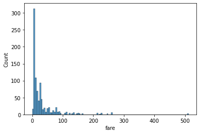

```python
sns.histplot(data.fare)
```

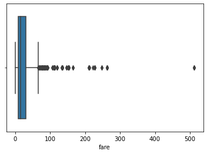

```python
sns.boxplot(data.fare)
```

```python
data.fare.describe()
```

```
count    891.000000
mean      32.204208
std       49.693429
min        0.000000
25%        7.910400
50%       14.454200
75%       31.000000
max      512.329200
Name: fare, dtype: float64
```

- 0 ~ 7.9104 : 1번 그룹
- 7.9104 ~ 14.4542 : 2번 그룹
- 14.4542 ~ 31 : 3번 그룹
- 31~ 512 : 4번 그룹

```python
data_fare01 = data.loc[(data.fare >= 0) & (data.fare < 7.9104), :]
print(data_fare01.shape)
data_fare01.head()
```

```
(223, 15)
```

|  | survived | pclass | sex | age | sibsp | parch | fare | embarked | class | who | adult_male | deck | embark_town | alive | alone |
| --- | --- | --- | --- | --- | --- | --- | --- | --- | --- | --- | --- | --- | --- | --- | --- |
| 0 | 0 | 3 | male | 22.0 | 1 | 0 | 7.2500 | S | Third | man | True | NaN | Southampton | no | False |
| 14 | 0 | 3 | female | 14.0 | 0 | 0 | 7.8542 | S | Third | child | False | NaN | Southampton | no | True |
| 19 | 1 | 3 | female | NaN | 0 | 0 | 7.2250 | C | Third | woman | False | NaN | Cherbourg | yes | True |
| 26 | 0 | 3 | male | NaN | 0 | 0 | 7.2250 | C | Third | man | True | NaN | Cherbourg | no | True |
| 28 | 1 | 3 | female | NaN | 0 | 0 | 7.8792 | Q | Third | woman | False | NaN | Queenstown | yes | True |

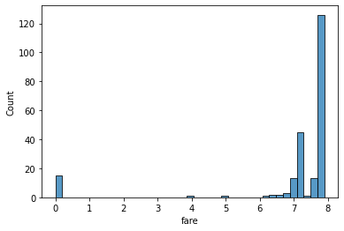

```python
sns.histplot(data_fare01.fare)
```

```python
data_fare02 = data.loc[(data.fare >= 7.9104) & (data.fare < 14.4542), :]
print(data_fare02.shape)
data_fare02.head()
```

```
(217, 15)
```

|  | survived | pclass | sex | age | sibsp | parch | fare | embarked | class | who | adult_male | deck | embark_town | alive | alone |
| --- | --- | --- | --- | --- | --- | --- | --- | --- | --- | --- | --- | --- | --- | --- | --- |
| 2 | 1 | 3 | female | 26.0 | 0 | 0 | 7.9250 | S | Third | woman | False | NaN | Southampton | yes | True |
| 4 | 0 | 3 | male | 35.0 | 0 | 0 | 8.0500 | S | Third | man | True | NaN | Southampton | no | True |
| 5 | 0 | 3 | male | NaN | 0 | 0 | 8.4583 | Q | Third | man | True | NaN | Queenstown | no | True |
| 8 | 1 | 3 | female | 27.0 | 0 | 2 | 11.1333 | S | Third | woman | False | NaN | Southampton | yes | False |
| 12 | 0 | 3 | male | 20.0 | 0 | 0 | 8.0500 | S | Third | man | True | NaN | Southampton | no | True |

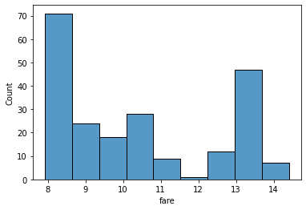

```python
sns.histplot(data_fare02.fare)
```

```python
data_fare03 = data.loc[(data.fare >= 14.4542) & (data.fare < 31), :]
print(data_fare03.shape)
data_fare03.head()
```

```
(226, 15)
```

|  | survived | pclass | sex | age | sibsp | parch | fare | embarked | class | who | adult_male | deck | embark_town | alive | alone |
| --- | --- | --- | --- | --- | --- | --- | --- | --- | --- | --- | --- | --- | --- | --- | --- |
| 7 | 0 | 3 | male | 2.0 | 3 | 1 | 21.0750 | S | Third | child | False | NaN | Southampton | no | False |
| 9 | 1 | 2 | female | 14.0 | 1 | 0 | 30.0708 | C | Second | child | False | NaN | Cherbourg | yes | False |
| 10 | 1 | 3 | female | 4.0 | 1 | 1 | 16.7000 | S | Third | child | False | G | Southampton | yes | False |
| 11 | 1 | 1 | female | 58.0 | 0 | 0 | 26.5500 | S | First | woman | False | C | Southampton | yes | True |
| 15 | 1 | 2 | female | 55.0 | 0 | 0 | 16.0000 | S | Second | woman | False | NaN | Southampton | yes | True |

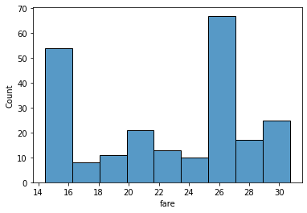

```python
sns.histplot(data_fare03.fare)
```

```python
data_fare04 = data.loc[(data.fare >= 31) & (data.fare <= 512), :]
print(data_fare04.shape)
data_fare04.head()
```

```
(222, 15)
```

|  | survived | pclass | sex | age | sibsp | parch | fare | embarked | class | who | adult_male | deck | embark_town | alive | alone |
| --- | --- | --- | --- | --- | --- | --- | --- | --- | --- | --- | --- | --- | --- | --- | --- |
| 1 | 1 | 1 | female | 38.0 | 1 | 0 | 71.2833 | C | First | woman | False | C | Cherbourg | yes | False |
| 3 | 1 | 1 | female | 35.0 | 1 | 0 | 53.1000 | S | First | woman | False | C | Southampton | yes | False |
| 6 | 0 | 1 | male | 54.0 | 0 | 0 | 51.8625 | S | First | man | True | E | Southampton | no | True |
| 13 | 0 | 3 | male | 39.0 | 1 | 5 | 31.2750 | S | Third | man | True | NaN | Southampton | no | False |
| 23 | 1 | 1 | male | 28.0 | 0 | 0 | 35.5000 | S | First | man | True | A | Southampton | yes | True |

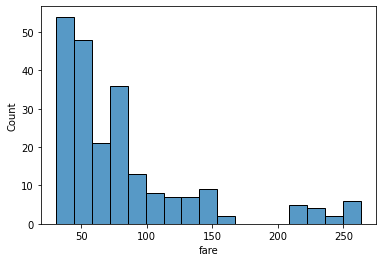

```python
sns.histplot(data_fare04.fare)
```

#### 6-2 (추가) 새로운 컬럼을 추가해서 1,2,3,4을 달아보자.

- 0 ~ 7.9104 : 1번 그룹
- 7.9104 ~ 14.4542 : 2번 그룹
- 14.4542 ~ 31 : 3번 그룹
- 31~ 512 : 4번 그룹

```python
data.loc[(data.fare >= 0) & (data.fare < 7.9104), "group_fare"] = 1
data.loc[(data.fare >= 7.9104) & (data.fare < 14.4542), "group_fare"] = 2
data.loc[(data.fare >= 14.4542) & (data.fare < 31), "group_fare"] = 3
data.loc[(data.fare >= 31) & (data.fare <= 512), "group_fare"] = 4
data
```

|  | survived | pclass | sex | age | sibsp | parch | fare | embarked | class | who | adult_male | deck | embark_town | alive | alone | group_fare |
| --- | --- | --- | --- | --- | --- | --- | --- | --- | --- | --- | --- | --- | --- | --- | --- | --- |
| 0 | 0 | 3 | male | 22.0 | 1 | 0 | 7.2500 | S | Third | man | True | NaN | Southampton | no | False | 1.0 |
| 1 | 1 | 1 | female | 38.0 | 1 | 0 | 71.2833 | C | First | woman | False | C | Cherbourg | yes | False | 4.0 |
| 2 | 1 | 3 | female | 26.0 | 0 | 0 | 7.9250 | S | Third | woman | False | NaN | Southampton | yes | True | 2.0 |
| 3 | 1 | 1 | female | 35.0 | 1 | 0 | 53.1000 | S | First | woman | False | C | Southampton | yes | False | 4.0 |
| 4 | 0 | 3 | male | 35.0 | 0 | 0 | 8.0500 | S | Third | man | True | NaN | Southampton | no | True | 2.0 |
| ... | ... | ... | ... | ... | ... | ... | ... | ... | ... | ... | ... | ... | ... | ... | ... | ... |
| 886 | 0 | 2 | male | 27.0 | 0 | 0 | 13.0000 | S | Second | man | True | NaN | Southampton | no | True | 2.0 |
| 887 | 1 | 1 | female | 19.0 | 0 | 0 | 30.0000 | S | First | woman | False | B | Southampton | yes | True | 3.0 |
| 888 | 0 | 3 | female | NaN | 1 | 2 | 23.4500 | S | Third | woman | False | NaN | Southampton | no | False | 3.0 |
| 889 | 1 | 1 | male | 26.0 | 0 | 0 | 30.0000 | C | First | man | True | C | Cherbourg | yes | True | 3.0 |
| 890 | 0 | 3 | male | 32.0 | 0 | 0 | 7.7500 | Q | Third | man | True | NaN | Queenstown | no | True | 1.0 |

891 rows × 16 columns

#### 6-3 (실습) age를 적정한 그룹으로 나누어서 이를 그래프로 표현해 보기(histgram)

```python
data.age.describe()
```

```
count    714.000000
mean      29.699118
std       14.526497
min        0.420000
25%       20.125000
50%       28.000000
75%       38.000000
max       80.000000
Name: age, dtype: float64
```

```python
data_age01 = data.loc[data["age"] < 20.125, :]
print(data_age01.shape)
data_age01.head()
```

```
(179, 16)
```

|  | survived | pclass | sex | age | sibsp | parch | fare | embarked | class | who | adult_male | deck | embark_town | alive | alone | group_fare |
| --- | --- | --- | --- | --- | --- | --- | --- | --- | --- | --- | --- | --- | --- | --- | --- | --- |
| 7 | 0 | 3 | male | 2.0 | 3 | 1 | 21.0750 | S | Third | child | False | NaN | Southampton | no | False | 3.0 |
| 9 | 1 | 2 | female | 14.0 | 1 | 0 | 30.0708 | C | Second | child | False | NaN | Cherbourg | yes | False | 3.0 |
| 10 | 1 | 3 | female | 4.0 | 1 | 1 | 16.7000 | S | Third | child | False | G | Southampton | yes | False | 3.0 |
| 12 | 0 | 3 | male | 20.0 | 0 | 0 | 8.0500 | S | Third | man | True | NaN | Southampton | no | True | 2.0 |
| 14 | 0 | 3 | female | 14.0 | 0 | 0 | 7.8542 | S | Third | child | False | NaN | Southampton | no | True | 1.0 |

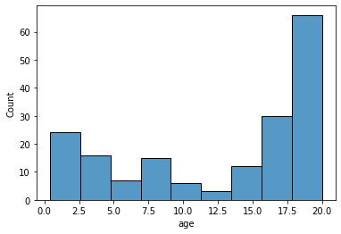

```python
sns.histplot(data_age01.age)
```

```python
data_age02 = data.loc[(data["age"] >= 20.125) & (data["age"] < 28), :]
print(data_age02.shape)
data_age02.head()
```

```
(158, 16)
```

|  | survived | pclass | sex | age | sibsp | parch | fare | embarked | class | who | adult_male | deck | embark_town | alive | alone | group_fare |
| --- | --- | --- | --- | --- | --- | --- | --- | --- | --- | --- | --- | --- | --- | --- | --- | --- |
| 0 | 0 | 3 | male | 22.0 | 1 | 0 | 7.2500 | S | Third | man | True | NaN | Southampton | no | False | 1.0 |
| 2 | 1 | 3 | female | 26.0 | 0 | 0 | 7.9250 | S | Third | woman | False | NaN | Southampton | yes | True | 2.0 |
| 8 | 1 | 3 | female | 27.0 | 0 | 2 | 11.1333 | S | Third | woman | False | NaN | Southampton | yes | False | 2.0 |
| 37 | 0 | 3 | male | 21.0 | 0 | 0 | 8.0500 | S | Third | man | True | NaN | Southampton | no | True | 2.0 |
| 41 | 0 | 2 | female | 27.0 | 1 | 0 | 21.0000 | S | Second | woman | False | NaN | Southampton | no | False | 3.0 |

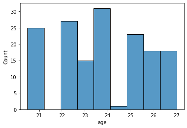

```python
sns.histplot(data_age02.age)
```

```python
data_age03 = data.loc[(data["age"] >= 28) & (data["age"] < 38), :]
print(data_age03.shape)
data_age03.head()
```

```
(189, 16)
```

|  | survived | pclass | sex | age | sibsp | parch | fare | embarked | class | who | adult_male | deck | embark_town | alive | alone | group_fare |
| --- | --- | --- | --- | --- | --- | --- | --- | --- | --- | --- | --- | --- | --- | --- | --- | --- |
| 3 | 1 | 1 | female | 35.0 | 1 | 0 | 53.10 | S | First | woman | False | C | Southampton | yes | False | 4.0 |
| 4 | 0 | 3 | male | 35.0 | 0 | 0 | 8.05 | S | Third | man | True | NaN | Southampton | no | True | 2.0 |
| 18 | 0 | 3 | female | 31.0 | 1 | 0 | 18.00 | S | Third | woman | False | NaN | Southampton | no | False | 3.0 |
| 20 | 0 | 2 | male | 35.0 | 0 | 0 | 26.00 | S | Second | man | True | NaN | Southampton | no | True | 3.0 |
| 21 | 1 | 2 | male | 34.0 | 0 | 0 | 13.00 | S | Second | man | True | D | Southampton | yes | True | 2.0 |

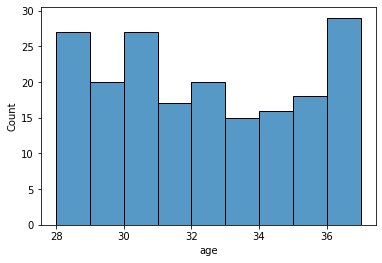

```python
sns.histplot(data_age03.age)
```

```python
data_age04 = data.loc[data["age"] >= 38, :]
print(data_age04.shape)
data_age04.head()
```

```
(188, 16)
```

|  | survived | pclass | sex | age | sibsp | parch | fare | embarked | class | who | adult_male | deck | embark_town | alive | alone | group_fare |
| --- | --- | --- | --- | --- | --- | --- | --- | --- | --- | --- | --- | --- | --- | --- | --- | --- |
| 1 | 1 | 1 | female | 38.0 | 1 | 0 | 71.2833 | C | First | woman | False | C | Cherbourg | yes | False | 4.0 |
| 6 | 0 | 1 | male | 54.0 | 0 | 0 | 51.8625 | S | First | man | True | E | Southampton | no | True | 4.0 |
| 11 | 1 | 1 | female | 58.0 | 0 | 0 | 26.5500 | S | First | woman | False | C | Southampton | yes | True | 3.0 |
| 13 | 0 | 3 | male | 39.0 | 1 | 5 | 31.2750 | S | Third | man | True | NaN | Southampton | no | False | 4.0 |
| 15 | 1 | 2 | female | 55.0 | 0 | 0 | 16.0000 | S | Second | woman | False | NaN | Southampton | yes | True | 3.0 |

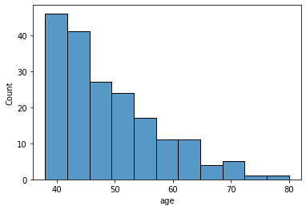

```python
sns.histplot(data_age04.age)
```

#### 6-3 (추가) 이 구분을 토대로 age에 대한 히스토그램을 그려보기 - 댓글

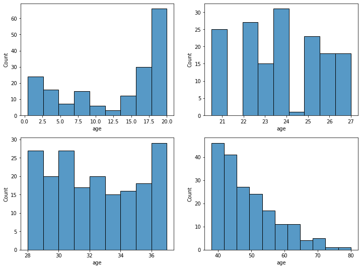

```python
import matplotlib.pyplot as plt

plt.figure(figsize=(12,9))
plt.subplot(2,2,1)
sns.histplot(data_age01.age)
plt.subplot(2,2,2)
sns.histplot(data_age02.age)
plt.subplot(2,2,3)
sns.histplot(data_age03.age)
plt.subplot(2,2,4)
sns.histplot(data_age04.age)
```

### 1. data를 age에 따라 4개 그룹으로 나누고, 새로운 'group_age' 컬럼을 부여한다.

### 2. 각 그룹에 속하는 행에 'group_Age' 값을 부여한다.

```python
data.loc[data["age"] < 20.125, 'group_age'] = 1
data.loc[(data["age"] >= 20.125) & (data["age"] < 28), 'group_age'] = 2
data.loc[(data["age"] >= 28) & (data["age"] < 38), 'group_age'] = 3
data.loc[data["age"] >= 38, 'group_age'] = 4
data
```

|  | survived | pclass | sex | age | sibsp | parch | fare | embarked | class | who | adult_male | deck | embark_town | alive | alone | group_fare | group_age |
| --- | --- | --- | --- | --- | --- | --- | --- | --- | --- | --- | --- | --- | --- | --- | --- | --- | --- |
| 0 | 0 | 3 | male | 22.0 | 1 | 0 | 7.2500 | S | Third | man | True | NaN | Southampton | no | False | 1.0 | 2.0 |
| 1 | 1 | 1 | female | 38.0 | 1 | 0 | 71.2833 | C | First | woman | False | C | Cherbourg | yes | False | 4.0 | 4.0 |
| 2 | 1 | 3 | female | 26.0 | 0 | 0 | 7.9250 | S | Third | woman | False | NaN | Southampton | yes | True | 2.0 | 2.0 |
| 3 | 1 | 1 | female | 35.0 | 1 | 0 | 53.1000 | S | First | woman | False | C | Southampton | yes | False | 4.0 | 3.0 |
| 4 | 0 | 3 | male | 35.0 | 0 | 0 | 8.0500 | S | Third | man | True | NaN | Southampton | no | True | 2.0 | 3.0 |
| ... | ... | ... | ... | ... | ... | ... | ... | ... | ... | ... | ... | ... | ... | ... | ... | ... | ... |
| 886 | 0 | 2 | male | 27.0 | 0 | 0 | 13.0000 | S | Second | man | True | NaN | Southampton | no | True | 2.0 | 2.0 |
| 887 | 1 | 1 | female | 19.0 | 0 | 0 | 30.0000 | S | First | woman | False | B | Southampton | yes | True | 3.0 | 1.0 |
| 888 | 0 | 3 | female | NaN | 1 | 2 | 23.4500 | S | Third | woman | False | NaN | Southampton | no | False | 3.0 | NaN |
| 889 | 1 | 1 | male | 26.0 | 0 | 0 | 30.0000 | C | First | man | True | C | Cherbourg | yes | True | 3.0 | 2.0 |
| 890 | 0 | 3 | male | 32.0 | 0 | 0 | 7.7500 | Q | Third | man | True | NaN | Queenstown | no | True | 1.0 | 3.0 |

891 rows × 17 columns

```python
grp_age_01 = data[ data['group_age'] == 1 ]
grp_age_02 = data[ data['group_age'] == 2 ]
grp_age_03 = data[ data['group_age'] == 3 ]
grp_age_04 = data[ data['group_age'] == 4 ]

grp_age_01.shape, grp_age_02.shape, grp_age_03.shape, grp_age_04.shape
```

```
((179, 17), (158, 17), (189, 17), (188, 17))
```

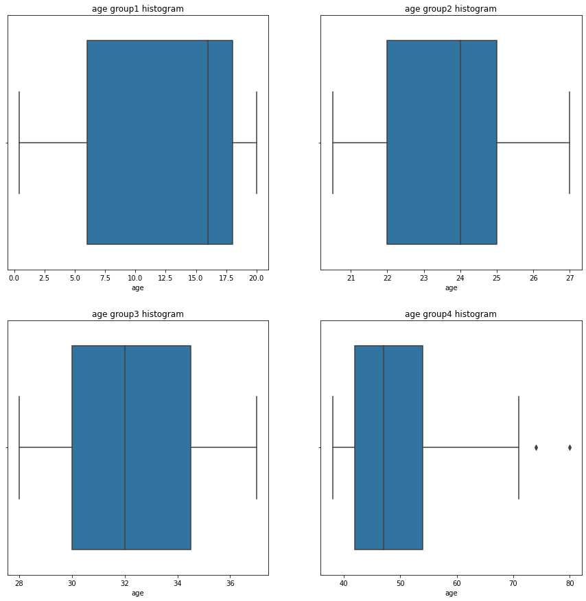

```python
# 전체 크기
plt.figure(figsize=(15,15))
plt.subplot(2,2,1)
sns.boxplot(x='age', data=grp_age_01)
plt.title("age group1 histogram")

plt.subplot(2,2,2)
sns.boxplot(x='age', data=grp_age_02)
plt.title("age group2 histogram")

plt.subplot(2,2,3)
sns.boxplot(x='age', data=grp_age_03)
plt.title("age group3 histogram")

plt.subplot(2,2,4)
sns.boxplot(x='age', data=grp_age_04)
plt.title("age group4 histogram")
```

## Groupby

```python
data
```

|  | survived | pclass | sex | age | sibsp | parch | fare | embarked | class | who | adult_male | deck | embark_town | alive | alone | group_fare | group_age |
| --- | --- | --- | --- | --- | --- | --- | --- | --- | --- | --- | --- | --- | --- | --- | --- | --- | --- |
| 0 | 0 | 3 | male | 22.0 | 1 | 0 | 7.2500 | S | Third | man | True | NaN | Southampton | no | False | 1.0 | 2.0 |
| 1 | 1 | 1 | female | 38.0 | 1 | 0 | 71.2833 | C | First | woman | False | C | Cherbourg | yes | False | 4.0 | 4.0 |
| 2 | 1 | 3 | female | 26.0 | 0 | 0 | 7.9250 | S | Third | woman | False | NaN | Southampton | yes | True | 2.0 | 2.0 |
| 3 | 1 | 1 | female | 35.0 | 1 | 0 | 53.1000 | S | First | woman | False | C | Southampton | yes | False | 4.0 | 3.0 |
| 4 | 0 | 3 | male | 35.0 | 0 | 0 | 8.0500 | S | Third | man | True | NaN | Southampton | no | True | 2.0 | 3.0 |
| ... | ... | ... | ... | ... | ... | ... | ... | ... | ... | ... | ... | ... | ... | ... | ... | ... | ... |
| 886 | 0 | 2 | male | 27.0 | 0 | 0 | 13.0000 | S | Second | man | True | NaN | Southampton | no | True | 2.0 | 2.0 |
| 887 | 1 | 1 | female | 19.0 | 0 | 0 | 30.0000 | S | First | woman | False | B | Southampton | yes | True | 3.0 | 1.0 |
| 888 | 0 | 3 | female | NaN | 1 | 2 | 23.4500 | S | Third | woman | False | NaN | Southampton | no | False | 3.0 | NaN |
| 889 | 1 | 1 | male | 26.0 | 0 | 0 | 30.0000 | C | First | man | True | C | Cherbourg | yes | True | 3.0 | 2.0 |
| 890 | 0 | 3 | male | 32.0 | 0 | 0 | 7.7500 | Q | Third | man | True | NaN | Queenstown | no | True | 1.0 | 3.0 |

891 rows × 17 columns

```python
# column을 group_fare로 구분
data.groupby(['group_fare'])
```

```
<pandas.core.groupby.generic.DataFrameGroupBy object at 0x000002957E79ABB0>
```

```python
# column을 group_fare로 구분한 값을 그룹별로 평균
data.groupby(['group_fare']).mean()
```

| group_fare | survived | pclass | age | sibsp | parch | fare | adult_male | alone | group_age |
| --- | --- | --- | --- | --- | --- | --- | --- | --- | --- |
| 1.0 | 0.197309 | 2.919283 | 28.328671 | 0.053812 | 0.022422 | 7.034172 | 0.802691 | 0.941704 | 2.363636 |
| 2.0 | 0.308756 | 2.603687 | 29.136186 | 0.129032 | 0.092166 | 10.254819 | 0.695853 | 0.861751 | 2.484536 |
| 3.0 | 0.442478 | 2.265487 | 28.860939 | 0.761062 | 0.610619 | 22.657281 | 0.491150 | 0.323009 | 2.535912 |
| 4.0 | 0.576577 | 1.468468 | 31.978860 | 1.144144 | 0.792793 | 82.173423 | 0.423423 | 0.292793 | 2.725389 |

```python
# column을 group_fare로 구분한 값을 그룹별로 합계
data.groupby(['group_fare']).sum()
```

| group_fare | survived | pclass | age | sibsp | parch | fare | adult_male | alone | group_age |
| --- | --- | --- | --- | --- | --- | --- | --- | --- | --- |
| 1.0 | 44 | 651 | 4051.00 | 12 | 5 | 1568.6203 | 179 | 210 | 338.0 |
| 2.0 | 67 | 565 | 5652.42 | 28 | 20 | 2225.2958 | 151 | 187 | 482.0 |
| 3.0 | 100 | 512 | 5223.83 | 172 | 138 | 5120.5456 | 111 | 73 | 459.0 |
| 4.0 | 128 | 326 | 6171.92 | 254 | 176 | 18242.5000 | 94 | 65 | 526.0 |

```python
# data에서 sel에 있는 column값만 골라서 group_fare로 구분하여 그룹별로 평균
sel = ['pclass', 'sex', 'age', 'fare', 'group_fare']
data[sel].groupby(['group_fare']).mean()
```

| group_fare | pclass | age | fare |
| --- | --- | --- | --- |
| 1.0 | 2.919283 | 28.328671 | 7.034172 |
| 2.0 | 2.603687 | 29.136186 | 10.254819 |
| 3.0 | 2.265487 | 28.860939 | 22.657281 |
| 4.0 | 1.468468 | 31.978860 | 82.173423 |

```python
sel = ['pclass', 'sex', 'age', 'fare', 'group_fare']
data[sel].groupby(['group_fare']).count()
```

| group_fare | pclass | sex | age | fare |
| --- | --- | --- | --- | --- |
| 1.0 | 223 | 223 | 143 | 223 |
| 2.0 | 217 | 217 | 194 | 217 |
| 3.0 | 226 | 226 | 181 | 226 |
| 4.0 | 222 | 222 | 193 | 222 |

```python
data.groupby(['sex']).sum()
```

| sex | survived | pclass | age | sibsp | parch | fare | adult_male | alone | group_fare | group_age |
| --- | --- | --- | --- | --- | --- | --- | --- | --- | --- | --- |
| female | 233 | 678 | 7286.00 | 218 | 204 | 13966.6628 | 0 | 126 | 902.0 | 638.0 |
| male | 109 | 1379 | 13919.17 | 248 | 136 | 14727.2865 | 537 | 411 | 1321.0 | 1176.0 |

```python
data.groupby(['sex']).count()
```

| sex | survived | pclass | age | sibsp | parch | fare | embarked | class | who | adult_male | deck | embark_town | alive | alone | group_fare | group_age |
| --- | --- | --- | --- | --- | --- | --- | --- | --- | --- | --- | --- | --- | --- | --- | --- | --- |
| female | 314 | 314 | 261 | 314 | 314 | 314 | 312 | 314 | 314 | 314 | 97 | 312 | 314 | 314 | 313 | 261 |
| male | 577 | 577 | 453 | 577 | 577 | 577 | 577 | 577 | 577 | 577 | 106 | 577 | 577 | 577 | 575 | 453 |

```python
# sex, pclass column을 기준으로 분류
data.groupby(['sex','pclass']).count()
```

| sex | pclass | survived | age | sibsp | parch | fare | embarked | class | who | adult_male | deck | embark_town | alive | alone | group_fare | group_age |
| --- | --- | --- | --- | --- | --- | --- | --- | --- | --- | --- | --- | --- | --- | --- | --- | --- |
| female | 1 | 94 | 85 | 94 | 94 | 94 | 92 | 94 | 94 | 94 | 81 | 92 | 94 | 94 | 93 | 85 |
|  | 2 | 76 | 74 | 76 | 76 | 76 | 76 | 76 | 76 | 76 | 10 | 76 | 76 | 76 | 76 | 74 |
|  | 3 | 144 | 102 | 144 | 144 | 144 | 144 | 144 | 144 | 144 | 6 | 144 | 144 | 144 | 144 | 102 |
| male | 1 | 122 | 101 | 122 | 122 | 122 | 122 | 122 | 122 | 122 | 94 | 122 | 122 | 122 | 120 | 101 |
|  | 2 | 108 | 99 | 108 | 108 | 108 | 108 | 108 | 108 | 108 | 6 | 108 | 108 | 108 | 108 | 99 |
|  | 3 | 347 | 253 | 347 | 347 | 347 | 347 | 347 | 347 | 347 | 6 | 347 | 347 | 347 | 347 | 253 |

```python
data.groupby(['sex','pclass','embarked']).count()
```

| sex | pclass | embarked | survived | age | sibsp | parch | fare | class | who | adult_male | deck | embark_town | alive | alone | group_fare | group_age |
| --- | --- | --- | --- | --- | --- | --- | --- | --- | --- | --- | --- | --- | --- | --- | --- | --- |
| female | 1 | C | 43 | 38 | 43 | 43 | 43 | 43 | 43 | 43 | 35 | 43 | 43 | 43 | 42 | 38 |
|  |  | Q | 1 | 1 | 1 | 1 | 1 | 1 | 1 | 1 | 1 | 1 | 1 | 1 | 1 | 1 |
|  |  | S | 48 | 44 | 48 | 48 | 48 | 48 | 48 | 48 | 43 | 48 | 48 | 48 | 48 | 44 |
|  | 2 | C | 7 | 7 | 7 | 7 | 7 | 7 | 7 | 7 | 1 | 7 | 7 | 7 | 7 | 7 |
|  |  | Q | 2 | 1 | 2 | 2 | 2 | 2 | 2 | 2 | 1 | 2 | 2 | 2 | 2 | 1 |
|  |  | S | 67 | 66 | 67 | 67 | 67 | 67 | 67 | 67 | 8 | 67 | 67 | 67 | 67 | 66 |
|  | 3 | C | 23 | 16 | 23 | 23 | 23 | 23 | 23 | 23 | 1 | 23 | 23 | 23 | 23 | 16 |
|  |  | Q | 33 | 10 | 33 | 33 | 33 | 33 | 33 | 33 | 0 | 33 | 33 | 33 | 33 | 10 |
|  |  | S | 88 | 76 | 88 | 88 | 88 | 88 | 88 | 88 | 5 | 88 | 88 | 88 | 88 | 76 |
| male | 1 | C | 42 | 36 | 42 | 42 | 42 | 42 | 42 | 42 | 31 | 42 | 42 | 42 | 40 | 36 |
|  |  | Q | 1 | 1 | 1 | 1 | 1 | 1 | 1 | 1 | 1 | 1 | 1 | 1 | 1 | 1 |
|  |  | S | 79 | 64 | 79 | 79 | 79 | 79 | 79 | 79 | 62 | 79 | 79 | 79 | 79 | 64 |
|  | 2 | C | 10 | 8 | 10 | 10 | 10 | 10 | 10 | 10 | 1 | 10 | 10 | 10 | 10 | 8 |
|  |  | Q | 1 | 1 | 1 | 1 | 1 | 1 | 1 | 1 | 0 | 1 | 1 | 1 | 1 | 1 |
|  |  | S | 97 | 90 | 97 | 97 | 97 | 97 | 97 | 97 | 5 | 97 | 97 | 97 | 97 | 90 |
|  | 3 | C | 43 | 25 | 43 | 43 | 43 | 43 | 43 | 43 | 0 | 43 | 43 | 43 | 43 | 25 |
|  |  | Q | 39 | 14 | 39 | 39 | 39 | 39 | 39 | 39 | 1 | 39 | 39 | 39 | 39 | 14 |
|  |  | S | 265 | 214 | 265 | 265 | 265 | 265 | 265 | 265 | 5 | 265 | 265 | 265 | 265 | 214 |

```python
data.groupby(['sex','pclass','embarked', 'group_age']).count()
```

| sex | pclass | embarked | group_age | survived | age | sibsp | parch | fare | class | who | adult_male | deck | embark_town | alive | alone | group_fare |
| --- | --- | --- | --- | --- | --- | --- | --- | --- | --- | --- | --- | --- | --- | --- | --- | --- |
| female | 1 | C | 1.0 | 5 | 5 | 5 | 5 | 5 | 5 | 5 | 5 | 5 | 5 | 5 | 5 | 5 |
|  |  |  | 2.0 | 7 | 7 | 7 | 7 | 7 | 7 | 7 | 7 | 7 | 7 | 7 | 7 | 7 |
|  |  |  | 3.0 | 7 | 7 | 7 | 7 | 7 | 7 | 7 | 7 | 4 | 7 | 7 | 7 | 6 |
|  |  |  | 4.0 | 19 | 19 | 19 | 19 | 19 | 19 | 19 | 19 | 17 | 19 | 19 | 19 | 19 |
|  |  | Q | 3.0 | 1 | 1 | 1 | 1 | 1 | 1 | 1 | 1 | 1 | 1 | 1 | 1 | 1 |
|  |  | S | 1.0 | 9 | 9 | 9 | 9 | 9 | 9 | 9 | 9 | 9 | 9 | 9 | 9 | 9 |
|  |  |  | 2.0 | 8 | 8 | 8 | 8 | 8 | 8 | 8 | 8 | 6 | 8 | 8 | 8 | 8 |
|  |  |  | 3.0 | 13 | 13 | 13 | 13 | 13 | 13 | 13 | 13 | 12 | 13 | 13 | 13 | 13 |
|  |  |  | 4.0 | 14 | 14 | 14 | 14 | 14 | 14 | 14 | 14 | 13 | 14 | 14 | 14 | 14 |
|  | 2 | C | 1.0 | 3 | 3 | 3 | 3 | 3 | 3 | 3 | 3 | 0 | 3 | 3 | 3 | 3 |
|  |  |  | 2.0 | 3 | 3 | 3 | 3 | 3 | 3 | 3 | 3 | 1 | 3 | 3 | 3 | 3 |
|  |  |  | 3.0 | 1 | 1 | 1 | 1 | 1 | 1 | 1 | 1 | 0 | 1 | 1 | 1 | 1 |
|  |  | Q | 3.0 | 1 | 1 | 1 | 1 | 1 | 1 | 1 | 1 | 0 | 1 | 1 | 1 | 1 |
|  |  | S | 1.0 | 13 | 13 | 13 | 13 | 13 | 13 | 13 | 13 | 1 | 13 | 13 | 13 | 13 |
|  |  |  | 2.0 | 14 | 14 | 14 | 14 | 14 | 14 | 14 | 14 | 2 | 14 | 14 | 14 | 14 |
|  |  |  | 3.0 | 22 | 22 | 22 | 22 | 22 | 22 | 22 | 22 | 4 | 22 | 22 | 22 | 22 |
|  |  |  | 4.0 | 17 | 17 | 17 | 17 | 17 | 17 | 17 | 17 | 1 | 17 | 17 | 17 | 17 |
|  | 3 | C | 1.0 | 13 | 13 | 13 | 13 | 13 | 13 | 13 | 13 | 0 | 13 | 13 | 13 | 13 |
|  |  |  | 2.0 | 1 | 1 | 1 | 1 | 1 | 1 | 1 | 1 | 0 | 1 | 1 | 1 | 1 |
|  |  |  | 3.0 | 1 | 1 | 1 | 1 | 1 | 1 | 1 | 1 | 0 | 1 | 1 | 1 | 1 |
|  |  |  | 4.0 | 1 | 1 | 1 | 1 | 1 | 1 | 1 | 1 | 0 | 1 | 1 | 1 | 1 |
|  |  | Q | 1.0 | 5 | 5 | 5 | 5 | 5 | 5 | 5 | 5 | 0 | 5 | 5 | 5 | 5 |
|  |  |  | 2.0 | 2 | 2 | 2 | 2 | 2 | 2 | 2 | 2 | 0 | 2 | 2 | 2 | 2 |
|  |  |  | 3.0 | 2 | 2 | 2 | 2 | 2 | 2 | 2 | 2 | 0 | 2 | 2 | 2 | 2 |
|  |  |  | 4.0 | 1 | 1 | 1 | 1 | 1 | 1 | 1 | 1 | 0 | 1 | 1 | 1 | 1 |
|  |  | S | 1.0 | 29 | 29 | 29 | 29 | 29 | 29 | 29 | 29 | 2 | 29 | 29 | 29 | 29 |
|  |  |  | 2.0 | 21 | 21 | 21 | 21 | 21 | 21 | 21 | 21 | 2 | 21 | 21 | 21 | 21 |
|  |  |  | 3.0 | 15 | 15 | 15 | 15 | 15 | 15 | 15 | 15 | 1 | 15 | 15 | 15 | 15 |
|  |  |  | 4.0 | 11 | 11 | 11 | 11 | 11 | 11 | 11 | 11 | 0 | 11 | 11 | 11 | 11 |
| male | 1 | C | 1.0 | 2 | 2 | 2 | 2 | 2 | 2 | 2 | 2 | 2 | 2 | 2 | 2 | 2 |
|  |  |  | 2.0 | 9 | 9 | 9 | 9 | 9 | 9 | 9 | 9 | 8 | 9 | 9 | 9 | 9 |
|  |  |  | 3.0 | 8 | 8 | 8 | 8 | 8 | 8 | 8 | 8 | 6 | 8 | 8 | 8 | 6 |
|  |  |  | 4.0 | 17 | 17 | 17 | 17 | 17 | 17 | 17 | 17 | 14 | 17 | 17 | 17 | 17 |
|  |  | Q | 4.0 | 1 | 1 | 1 | 1 | 1 | 1 | 1 | 1 | 1 | 1 | 1 | 1 | 1 |
|  |  | S | 1.0 | 5 | 5 | 5 | 5 | 5 | 5 | 5 | 5 | 5 | 5 | 5 | 5 | 5 |
|  |  |  | 2.0 | 3 | 3 | 3 | 3 | 3 | 3 | 3 | 3 | 2 | 3 | 3 | 3 | 3 |
|  |  |  | 3.0 | 17 | 17 | 17 | 17 | 17 | 17 | 17 | 17 | 15 | 17 | 17 | 17 | 17 |
|  |  |  | 4.0 | 39 | 39 | 39 | 39 | 39 | 39 | 39 | 39 | 30 | 39 | 39 | 39 | 39 |
|  | 2 | C | 1.0 | 1 | 1 | 1 | 1 | 1 | 1 | 1 | 1 | 0 | 1 | 1 | 1 | 1 |
|  |  |  | 2.0 | 2 | 2 | 2 | 2 | 2 | 2 | 2 | 2 | 0 | 2 | 2 | 2 | 2 |
|  |  |  | 3.0 | 5 | 5 | 5 | 5 | 5 | 5 | 5 | 5 | 1 | 5 | 5 | 5 | 5 |
|  |  | Q | 4.0 | 1 | 1 | 1 | 1 | 1 | 1 | 1 | 1 | 0 | 1 | 1 | 1 | 1 |
|  |  | S | 1.0 | 18 | 18 | 18 | 18 | 18 | 18 | 18 | 18 | 3 | 18 | 18 | 18 | 18 |
|  |  |  | 2.0 | 19 | 19 | 19 | 19 | 19 | 19 | 19 | 19 | 0 | 19 | 19 | 19 | 19 |
|  |  |  | 3.0 | 30 | 30 | 30 | 30 | 30 | 30 | 30 | 30 | 2 | 30 | 30 | 30 | 30 |
|  |  |  | 4.0 | 23 | 23 | 23 | 23 | 23 | 23 | 23 | 23 | 0 | 23 | 23 | 23 | 23 |
|  | 3 | C | 1.0 | 8 | 8 | 8 | 8 | 8 | 8 | 8 | 8 | 0 | 8 | 8 | 8 | 8 |
|  |  |  | 2.0 | 7 | 7 | 7 | 7 | 7 | 7 | 7 | 7 | 0 | 7 | 7 | 7 | 7 |
|  |  |  | 3.0 | 8 | 8 | 8 | 8 | 8 | 8 | 8 | 8 | 0 | 8 | 8 | 8 | 8 |
|  |  |  | 4.0 | 2 | 2 | 2 | 2 | 2 | 2 | 2 | 2 | 0 | 2 | 2 | 2 | 2 |
|  |  | Q | 1.0 | 5 | 5 | 5 | 5 | 5 | 5 | 5 | 5 | 0 | 5 | 5 | 5 | 5 |
|  |  |  | 2.0 | 2 | 2 | 2 | 2 | 2 | 2 | 2 | 2 | 0 | 2 | 2 | 2 | 2 |
|  |  |  | 3.0 | 3 | 3 | 3 | 3 | 3 | 3 | 3 | 3 | 0 | 3 | 3 | 3 | 3 |
|  |  |  | 4.0 | 4 | 4 | 4 | 4 | 4 | 4 | 4 | 4 | 0 | 4 | 4 | 4 | 4 |
|  |  | S | 1.0 | 63 | 63 | 63 | 63 | 63 | 63 | 63 | 63 | 2 | 63 | 63 | 63 | 63 |
|  |  |  | 2.0 | 60 | 60 | 60 | 60 | 60 | 60 | 60 | 60 | 1 | 60 | 60 | 60 | 60 |
|  |  |  | 3.0 | 55 | 55 | 55 | 55 | 55 | 55 | 55 | 55 | 1 | 55 | 55 | 55 | 55 |
|  |  |  | 4.0 | 36 | 36 | 36 | 36 | 36 | 36 | 36 | 36 | 1 | 36 | 36 | 36 | 36 |